# Madaraka_Day_Speech_Analysis

Allan Ouko

05/08/2021

# About the Project

This project involves analyzing President Uhuru’s Madaraka Day speech of 2020 and 2021. The project’s main aim is to gain insights of the general idea of the two speches. The project covers the following.

**Reading text data** **Tidying text data** **Creating and analyzing bigrams** **Visualization** **Sentiment analysis**

# 1: Loading the Required Packages

The project will require the following r packages installed and loaded.

```r
library(wordcloud) #for visualizing
library(tidyverse) #for various data manipulation tasks
library(tidytext) #for text mining specifically, main package in book
library(stringr) #for various text operations
library(readtext) # for reading in txt files
library(igraph) # for creating networks of bigrams
library(ggraph) # for visualizing networks of bigrams
```

# 2: Reading the Data in R

Since the data are in the Folder “Madaraka_Day_Speech,” we can read rge data in two ways:

## Reading all the files in the folder

```r
Speech = readtext("Madaraka_Day_Speech/")
```

## Reading individual files

Since we are working with two files only, we will also read the data innto r for further data manipulation.

```r
Speech_2020 = readtext("Madaraka_Day_Speech/2020.txt")
Speech_2021 = readtext("Madaraka_Day_Speech/2021.txt")
```

# 3: Tidying the Data

The data is in text format, hence the first step is to put it in a dataframe. For all the files;

```r
Speech_DF = tibble(line =1,text = Speech)
Speech_DF
```

```
## # A tibble: 2 x 2
##    line text$doc_id $text
##   <dbl> <chr>       <chr>
## 1     1 2020.txt    "Today’s celebration is taking place in an unconventional m~
## 2     1 2021.txt    "Fellow Kenyans,\n \nIt gives me great pleasure to celebrat~
```

For the individual files;

```r
Speech_2020_DF = tibble(line =1,text = Speech_2020)
Speech_2020_DF
```

```
## # A tibble: 1 x 2
##    line text$doc_id $text
##   <dbl> <chr>       <chr>
## 1     1 2020.txt    "Today’s celebration is taking place in an unconventional m~
```

```r
Speech_2021_DF = tibble(line =1,text = Speech_2021)
Speech_2021_DF
```

```
## # A tibble: 1 x 2
##    line text$doc_id $text
##   <dbl> <chr>       <chr>
## 1     1 2021.txt    "Fellow Kenyans,\n \nIt gives me great pleasure to celebrat~
```

## Further Text Analysis

Using unnest_tokens(), we convert the data into tidy format, remove the punctuation and converts the words into lower case

For all the files;

```r
Speech_tidy = Speech_DF %>%
  unnest_tokens(word, text) %>%
  anti_join(stop_words) %>% count(word,sort = T)
Speech_tidy
```

```
## # A tibble: 1,684 x 2
##    word             n
##    <chr>        <int>
##  1 kenya           43
##  2 kenyans         40
##  3 national        39
##  4 fathers         36
##  5 founding        36
##  6 kisumu          29
##  7 nation          28
##  8 fellow          27
##  9 day             25
## 10 constitution    23
## # ... with 1,674 more rows
```

For individual files;

```r
Speech_2020_tidy = Speech_2020_DF %>%
  unnest_tokens(word, text) %>%
  anti_join(stop_words) %>% count(word,sort = T)
Speech_2020_tidy
```

```
## # A tibble: 922 x 2
##    word             n
##    <chr>        <int>
##  1 nation          23
##  2 founding        21
##  3 fathers         20
##  4 kenya           20
##  5 dream           18
##  6 kenyans         18
##  7 constitution    17
##  8 fellow          11
##  9 moment          10
## 10 railway         10
## # ... with 912 more rows
```

```r
Speech_2021_tidy = Speech_2021_DF %>%
  unnest_tokens(word, text) %>%
  anti_join(stop_words) %>% count(word,sort = T)
Speech_2021_tidy
```

```
## # A tibble: 1,052 x 2
##    word         n
##    <chr>    <int>
##  1 national    31
##  2 kisumu      28
##  3 kenya       23
##  4 kenyans     22
##  5 day         16
##  6 fathers     16
##  7 fellow      16
##  8 burden      15
##  9 founding    15
## 10 port        15
## # ... with 1,042 more rows
```

## Removing numbers from the data.

We remove numbers which may make the analysis meaningless.

For all the files;

```r
Speech_no = Speech_tidy[-grep("^[0-9]+", Speech_tidy$word),]
Speech_no
```

```
## # A tibble: 1,585 x 2
##    word             n
##    <chr>        <int>
##  1 kenya           43
##  2 kenyans         40
##  3 national        39
##  4 fathers         36
##  5 founding        36
##  6 kisumu          29
##  7 nation          28
##  8 fellow          27
##  9 day             25
## 10 constitution    23
## # ... with 1,575 more rows
```

For the individual files;

```r
Speech_2020_no = Speech_2020_tidy[-grep("^[0-9]+", Speech_2020_tidy$word),]
Speech_2020_no
```

```
## # A tibble: 871 x 2
##    word             n
##    <chr>        <int>
##  1 nation          23
##  2 founding        21
##  3 fathers         20
##  4 kenya           20
##  5 dream           18
##  6 kenyans         18
##  7 constitution    17
##  8 fellow          11
##  9 moment          10
## 10 railway         10
## # ... with 861 more rows
```

```r
Speech_2021_no = Speech_2021_tidy[-grep("^[0-9]+", Speech_2021_tidy$word),]
Speech_2021_no
```

```
## # A tibble: 988 x 2
##    word         n
##    <chr>    <int>
##  1 national    31
##  2 kisumu      28
##  3 kenya       23
##  4 kenyans     22
##  5 day         16
##  6 fathers     16
##  7 fellow      16
##  8 burden      15
##  9 founding    15
## 10 port        15
## # ... with 978 more rows
```

## Analyzing the 2020 and 2021 speeches.

We analyze both the 2020 and 2021 speeches individualy, convert it to a tibble, remove the stopwords and numbers to get it ready for visualization.

### 2020 Speech

```r
Speech_2020_rem = Speech_2020 %>% tibble() %>%
  unnest_tokens(word, text) %>%
  anti_join(stop_words) %>% count(word,sort = T)
Speech_2020_rem
```

```
## # A tibble: 922 x 2
##    word             n
##    <chr>        <int>
##  1 nation          23
##  2 founding        21
##  3 fathers         20
##  4 kenya           20
##  5 dream           18
##  6 kenyans         18
##  7 constitution    17
##  8 fellow          11
##  9 moment          10
## 10 railway         10
## # ... with 912 more rows
```

```r
Speech_2020_Ready = Speech_2020_rem[-grep("^[0-9]+", Speech_2020_rem$word),] %>% filter(word != "page")
Speech_2020_Ready
```

```
## # A tibble: 871 x 2
##    word             n
##    <chr>        <int>
##  1 nation          23
##  2 founding        21
##  3 fathers         20
##  4 kenya           20
##  5 dream           18
##  6 kenyans         18
##  7 constitution    17
##  8 fellow          11
##  9 moment          10
## 10 railway         10
## # ... with 861 more rows
```

### 2021 Speech

```r
Speech_2021_rem = Speech_2021 %>% tibble() %>%
  unnest_tokens(word, text) %>%
  anti_join(stop_words) %>% group_by(doc_id) %>% count(word,sort = T)
Speech_2021_rem
```

```
## # A tibble: 1,052 x 3
## # Groups:   doc_id [1]
##    doc_id   word         n
##    <chr>    <chr>    <int>
##  1 2021.txt national    31
##  2 2021.txt kisumu      28
##  3 2021.txt kenya       23
##  4 2021.txt kenyans     22
##  5 2021.txt day         16
##  6 2021.txt fathers     16
##  7 2021.txt fellow      16
##  8 2021.txt burden      15
##  9 2021.txt founding    15
## 10 2021.txt port        15
## # ... with 1,042 more rows
```

```r
Speech_2021_Ready = Speech_2021_rem[-grep("^[0-9]+", Speech_2021_rem$word),] %>% filter(word != "page")
Speech_2021_Ready
```

```
## # A tibble: 988 x 3
## # Groups:   doc_id [1]
##    doc_id   word         n
##    <chr>    <chr>    <int>
##  1 2021.txt national    31
##  2 2021.txt kisumu      28
##  3 2021.txt kenya       23
##  4 2021.txt kenyans     22
##  5 2021.txt day         16
##  6 2021.txt fathers     16
##  7 2021.txt fellow      16
##  8 2021.txt burden      15
##  9 2021.txt founding    15
## 10 2021.txt port        15
## # ... with 978 more rows
```

# 4: Visualizing the Data in a Bar Graph Using ggplot2

## 2020 Speech

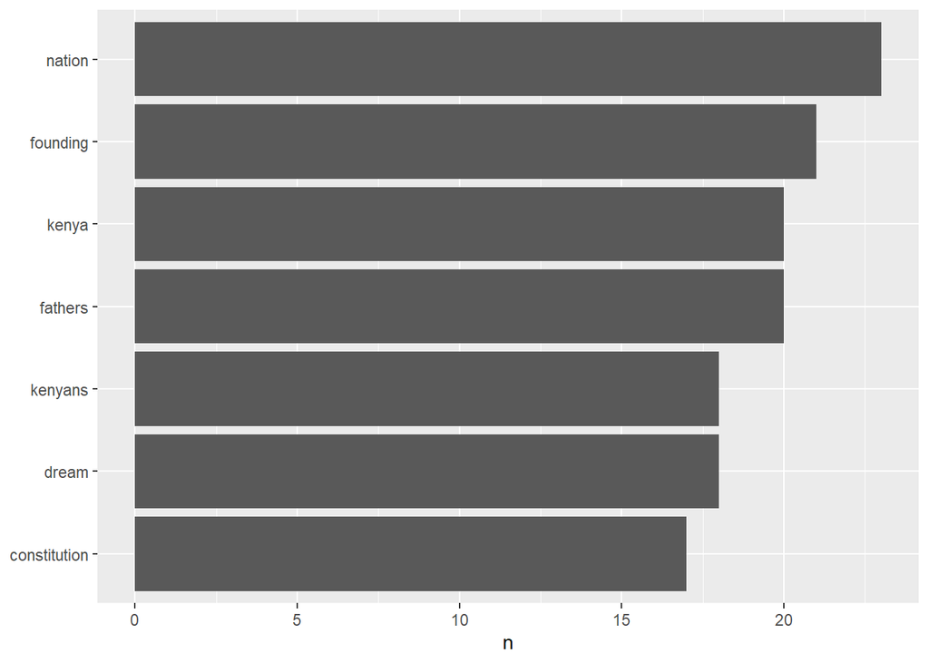

```r
Madaraka_2020_graph = Speech_2020_Ready %>%
  filter(n > 15) %>%
  mutate(word = reorder(word, n)) %>%
  ggplot(aes(word, n)) +
  geom_col() +
  xlab(NULL) +
  coord_flip()
Madaraka_2020_graph
```

## 2021 Speech

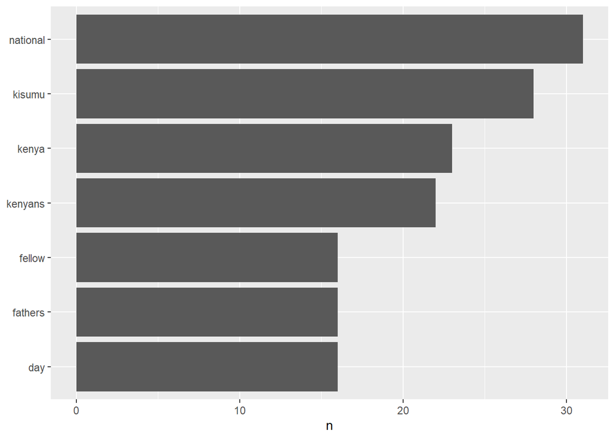

```r
Madaraka_2021_graph = Speech_2021_Ready %>%
  filter(n > 15) %>%
  mutate(word = reorder(word, n)) %>%
  ggplot(aes(word, n)) +
  geom_col() +
  xlab(NULL) +
  coord_flip()
Madaraka_2021_graph
```

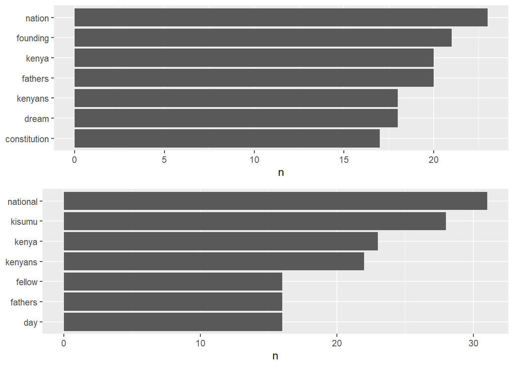

```r
library(gridExtra)
grid.arrange(Madaraka_2020_graph, Madaraka_2021_graph)
```

# 5: Term frequency and inverse document frequency (tf-idf)

tf-idf checks how important a word is to a document in a collection of documents. We check the words in the two files. Hence we use the ‘Speech’ file.

```r
Madaraka_Speech = Speech %>% tibble() %>%
  unnest_tokens(word, text) %>% count(doc_id,word,sort = T)
Madaraka_Speech
```

```
## # A tibble: 2,490 x 3
##    doc_id   word      n
##    <chr>    <chr> <int>
##  1 2021.txt the     348
##  2 2020.txt the     238
##  3 2021.txt of      216
##  4 2021.txt to      172
##  5 2020.txt of      147
##  6 2020.txt to      139
##  7 2020.txt and     132
##  8 2021.txt and     126
##  9 2021.txt is       96
## 10 2021.txt in       92
## # ... with 2,480 more rows
```

```r
Madaraka_Speech_DF = tibble(line =1,text = Madaraka_Speech)

Madaraka_Speech_no = Madaraka_Speech %>% anti_join(stop_words)
Madaraka_Speech_no
```

```
## # A tibble: 1,974 x 3
##    doc_id   word         n
##    <chr>    <chr>    <int>
##  1 2021.txt national    31
##  2 2021.txt kisumu      28
##  3 2020.txt nation      23
##  4 2021.txt kenya       23
##  5 2021.txt kenyans     22
##  6 2020.txt founding    21
##  7 2020.txt fathers     20
##  8 2020.txt kenya       20
##  9 2020.txt dream       18
## 10 2020.txt kenyans     18
## # ... with 1,964 more rows
```

The data shows there are some words that occur repeatedly in the text and may not be meaningful in the analysis. Hence we have to define the words and remove them and the numbers in the data.

```r
meaningless_words = tibble(word = c("kenya","fathers", "ksh", "founding", "kenyans", "fellow", "day", "nation", "national"))
Madaraka_Speech_rem = Madaraka_Speech_no %>% anti_join(meaningless_words)
Madaraka_Speech_rem
```

```
## # A tibble: 1,956 x 3
##    doc_id   word             n
##    <chr>    <chr>        <int>
##  1 2021.txt kisumu          28
##  2 2020.txt dream           18
##  3 2020.txt constitution    17
##  4 2021.txt burden          15
##  5 2021.txt port            15
##  6 2021.txt economic        14
##  7 2021.txt freedom         14
##  8 2021.txt people          14
##  9 2021.txt choice          13
## 10 2021.txt dignity         13
## # ... with 1,946 more rows
```

```r
Madaraka_Speech_tidy = Madaraka_Speech_rem[-grep("^[0-9]+", Madaraka_Speech_rem$word),] %>% filter(word != "page")
Madaraka_Speech_tidy
```

```
## # A tibble: 1,841 x 3
##    doc_id   word             n
##    <chr>    <chr>        <int>
##  1 2021.txt kisumu          28
##  2 2020.txt dream           18
##  3 2020.txt constitution    17
##  4 2021.txt burden          15
##  5 2021.txt port            15
##  6 2021.txt economic        14
##  7 2021.txt freedom         14
##  8 2021.txt people          14
##  9 2021.txt choice          13
## 10 2021.txt dignity         13
## # ... with 1,831 more rows
```

## check the total words in the data

```r
total_words = Madaraka_Speech_tidy %>% group_by(doc_id) %>%
  summarize(total = sum(n))
total_words
```

```
## # A tibble: 2 x 2
##   doc_id   total
##   <chr>    <int>
## 1 2020.txt  1402
## 2 2021.txt  1837
```

## Left join

The function merges the two tables with matching words.

```r
Madaraka_Speech_join = left_join(Madaraka_Speech_tidy, total_words)
Madaraka_Speech_join
```

```
## # A tibble: 1,841 x 4
##    doc_id   word             n total
##    <chr>    <chr>        <int> <int>
##  1 2021.txt kisumu          28  1837
##  2 2020.txt dream           18  1402
##  3 2020.txt constitution    17  1402
##  4 2021.txt burden          15  1837
##  5 2021.txt port            15  1837
##  6 2021.txt economic        14  1837
##  7 2021.txt freedom         14  1837
##  8 2021.txt people          14  1837
##  9 2021.txt choice          13  1837
## 10 2021.txt dignity         13  1837
## # ... with 1,831 more rows
```

## Term Frequency

```r
Madaraka_Speech_freq = Madaraka_Speech_join %>% mutate(rank = row_number(),tf = n/total)
Madaraka_Speech_freq
```

```
## # A tibble: 1,841 x 6
##    doc_id   word             n total  rank      tf
##    <chr>    <chr>        <int> <int> <int>   <dbl>
##  1 2021.txt kisumu          28  1837     1 0.0152
##  2 2020.txt dream           18  1402     2 0.0128
##  3 2020.txt constitution    17  1402     3 0.0121
##  4 2021.txt burden          15  1837     4 0.00817
##  5 2021.txt port            15  1837     5 0.00817
##  6 2021.txt economic        14  1837     6 0.00762
##  7 2021.txt freedom         14  1837     7 0.00762
##  8 2021.txt people          14  1837     8 0.00762
##  9 2021.txt choice          13  1837     9 0.00708
## 10 2021.txt dignity         13  1837    10 0.00708
## # ... with 1,831 more rows
```

## bind tf-idf function

```r
Speech_words_2020 = Madaraka_Speech_join %>%
  bind_tf_idf(word, doc_id , n) %>% arrange(desc(tf_idf))
Speech_words_2020 %>% filter(doc_id == "2020.txt")
```

```
## # A tibble: 862 x 7
##    doc_id   word            n total      tf   idf  tf_idf
##    <chr>    <chr>       <int> <int>   <dbl> <dbl>   <dbl>
##  1 2020.txt culture         7  1402 0.00499 0.693 0.00346
##  2 2020.txt pandemic        7  1402 0.00499 0.693 0.00346
##  3 2020.txt book            6  1402 0.00428 0.693 0.00297
##  4 2020.txt called          6  1402 0.00428 0.693 0.00297
##  5 2020.txt coronavirus     6  1402 0.00428 0.693 0.00297
##  6 2020.txt dreams          6  1402 0.00428 0.693 0.00297
##  7 2020.txt faith           5  1402 0.00357 0.693 0.00247
##  8 2020.txt households      5  1402 0.00357 0.693 0.00247
##  9 2020.txt published       5  1402 0.00357 0.693 0.00247
## 10 2020.txt act             4  1402 0.00285 0.693 0.00198
## # ... with 852 more rows
```

```r
Speech_words_2021 = Madaraka_Speech_join %>%
  bind_tf_idf(word, doc_id , n) %>% arrange(desc(tf_idf))
Speech_words_2021 %>% filter(doc_id == "2021.txt")
```

```
## # A tibble: 979 x 7
##    doc_id   word              n total      tf   idf  tf_idf
##    <chr>    <chr>         <int> <int>   <dbl> <dbl>   <dbl>
##  1 2021.txt burden           15  1837 0.00817 0.693 0.00566
##  2 2021.txt choice           13  1837 0.00708 0.693 0.00491
##  3 2021.txt road             11  1837 0.00599 0.693 0.00415
##  4 2021.txt bbi              10  1837 0.00544 0.693 0.00377
##  5 2021.txt choices          10  1837 0.00544 0.693 0.00377
##  6 2021.txt judiciary         9  1837 0.00490 0.693 0.00340
##  7 2021.txt dialysis          8  1837 0.00435 0.693 0.00302
##  8 2021.txt fuel              7  1837 0.00381 0.693 0.00264
##  9 2021.txt month             7  1837 0.00381 0.693 0.00264
## 10 2021.txt opportunities     7  1837 0.00381 0.693 0.00264
## # ... with 969 more rows
```

# 6: Sentiment Analysis/Opinion Mining

## Get the relevant dictionaries for Sentiment Analysis

```r
get_sentiments("afinn")
```

```
## # A tibble: 2,477 x 2
##    word       value
##    <chr>      <dbl>
##  1 abandon       -2
##  2 abandoned     -2
##  3 abandons      -2
##  4 abducted      -2
##  5 abduction     -2
##  6 abductions    -2
##  7 abhor         -3
##  8 abhorred      -3
##  9 abhorrent     -3
## 10 abhors        -3
## # ... with 2,467 more rows
```

```r
get_sentiments("bing")
```

```
## # A tibble: 6,786 x 2
##    word        sentiment
##    <chr>       <chr>
##  1 2-faces     negative
##  2 abnormal    negative
##  3 abolish     negative
##  4 abominable  negative
##  5 abominably  negative
##  6 abominate   negative
##  7 abomination negative
##  8 abort       negative
##  9 aborted     negative
## 10 aborts      negative
## # ... with 6,776 more rows
```

```r
get_sentiments("nrc")
```

```
## # A tibble: 13,901 x 2
##    word        sentiment
##    <chr>       <chr>
##  1 abacus      trust
##  2 abandon     fear
##  3 abandon     negative
##  4 abandon     sadness
##  5 abandoned   anger
##  6 abandoned   fear
##  7 abandoned   negative
##  8 abandoned   sadness
##  9 abandonment anger
## 10 abandonment fear
## # ... with 13,891 more rows
```

Get the sentiments expressed in the speech.

```r
Sentiments = Speech %>% tibble() %>%
  unnest_tokens(word, text) %>%
  anti_join(stop_words) %>% group_by(doc_id) %>% inner_join(get_sentiments("bing"))
Sentiments
```

```
## # A tibble: 417 x 3
## # Groups:   doc_id [2]
##    doc_id   word        sentiment
##    <chr>    <chr>       <chr>
##  1 2020.txt celebration positive
##  2 2020.txt unable      negative
##  3 2020.txt celebrate   positive
##  4 2020.txt celebrate   positive
##  5 2020.txt salute      positive
##  6 2020.txt happy       positive
##  7 2020.txt fond        positive
##  8 2020.txt struggle    negative
##  9 2020.txt struggle    negative
## 10 2020.txt defeated    positive
## # ... with 407 more rows
```

```r
### 2020 Speech
Sentiments %>% filter(doc_id == "2020.txt") %>% group_by(sentiment) %>% count(sentiment, sort = T)
```

```
## # A tibble: 2 x 2
## # Groups:   sentiment [2]
##   sentiment     n
##   <chr>     <int>
## 1 positive    109
## 2 negative     76
```

### 2021 Speech

```r
Sentiments %>% filter(doc_id == "2021.txt") %>% group_by(sentiment) %>% count(sentiment, sort = T)
```

```
## # A tibble: 2 x 2
## # Groups:   sentiment [2]
##   sentiment     n
##   <chr>     <int>
## 1 positive    147
## 2 negative     85
```

```r
Sentiments_analysis = function(x){
    sent = Sentiments %>%
    group_by(sentiment) %>%
    count(sentiment, sort = T)
    return(sent)}
```

```r
Sentiments_analysis("Speech")
```

```
## # A tibble: 2 x 2
## # Groups:   sentiment [2]
##   sentiment     n
##   <chr>     <int>
## 1 positive    256
## 2 negative    161
```

```r
Sentiments_analysis(filter(Speech, doc_id == "2020.txt"))
```

```
## # A tibble: 2 x 2
## # Groups:   sentiment [2]
##   sentiment     n
##   <chr>     <int>
## 1 positive    256
## 2 negative    161
```

# 7: WordCloud Visualization

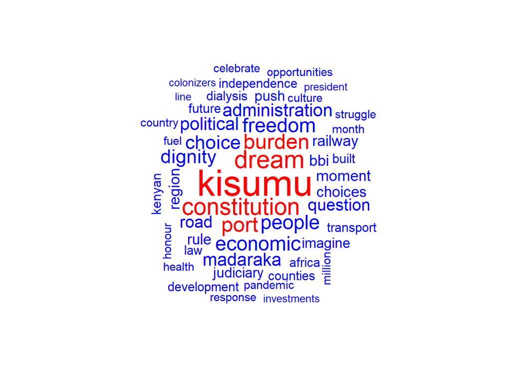

```r
Speech_words_2020 %>%
  with(wordcloud(unique(word), n, min.words = 1, max.words = 50, random.order = F
                 , color = c("blue", "red"), scale = c(3, 0.3)))
```

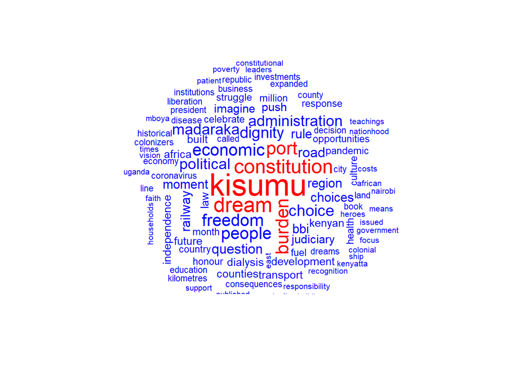

```r
Speech_words_2021 %>%
  with(wordcloud(unique(word), n, min.words = 1, max.words = 100, random.order = F
                 , color = c("blue", "red"), scale = c(2.5, 0.25)))
```

# 8: Word Frequencies

We analyze the frequently used words in the speech.

```r
Madaraka_Speech_freq %>% count(word, sort = T)
```

```
## # A tibble: 1,576 x 2
##    word                 n
##    <chr>            <int>
##  1 achieve              2
##  2 achieved             2
##  3 achievements         2
##  4 action               2
##  5 added                2
##  6 address              2
##  7 administration       2
##  8 administration’s     2
##  9 administrations      2
## 10 africa               2
## # ... with 1,566 more rows
```

### 2020 Speech

```r
Speech_words_2020 %>% count(word, sort = T)
```

```
## # A tibble: 1,576 x 2
##    word                 n
##    <chr>            <int>
##  1 achieve              2
##  2 achieved             2
##  3 achievements         2
##  4 action               2
##  5 added                2
##  6 address              2
##  7 administration       2
##  8 administration’s     2
##  9 administrations      2
## 10 africa               2
## # ... with 1,566 more rows
```

### 2021 Speech

```r
Speech_words_2021 %>% count(word, sort = T)
```

```
## # A tibble: 1,576 x 2
##    word                 n
##    <chr>            <int>
##  1 achieve              2
##  2 achieved             2
##  3 achievements         2
##  4 action               2
##  5 added                2
##  6 address              2
##  7 administration       2
##  8 administration’s     2
##  9 administrations      2
## 10 africa               2
## # ... with 1,566 more rows
```

```r
Madaraka_Speech_F = Madaraka_Speech_tidy %>%
  group_by(doc_id) %>%
  count(word, sort = T)
head(Madaraka_Speech_F, 10)
```

```
## # A tibble: 10 x 3
## # Groups:   doc_id [1]
##    doc_id   word             n
##    <chr>    <chr>        <int>
##  1 2020.txt abandon          1
##  2 2020.txt abbey            1
##  3 2020.txt absolutely       1
##  4 2020.txt accord           1
##  5 2020.txt achieve          1
##  6 2020.txt achieved         1
##  7 2020.txt achievement      1
##  8 2020.txt achievements     1
##  9 2020.txt act              1
## 10 2020.txt action           1
```

## Plotting word frequencies with bar graphs

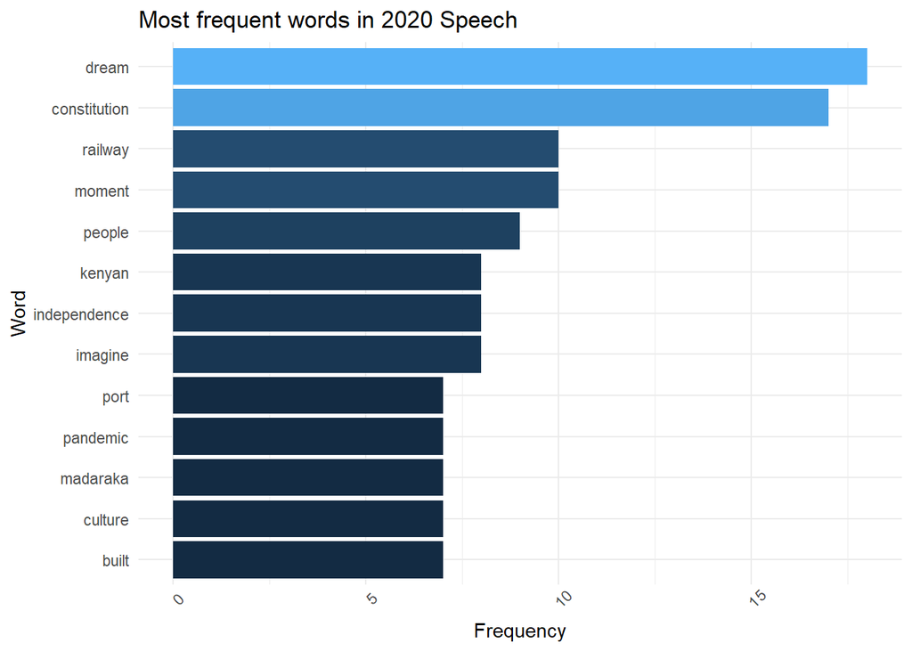

```r
Madaraka_Speech_tidy %>%
  filter(n>6 & doc_id == "2020.txt") %>%
  ggplot(aes(x=n, y=reorder(word, n), fill=n)) +
  geom_col(show.legend=FALSE) +
  labs(
    x = "Frequency",
    y = "Word",
    title = "Most frequent words in 2020 Speech"
  ) +
  theme_minimal() +
  theme(axis.text.x = element_text(angle = 45))
```

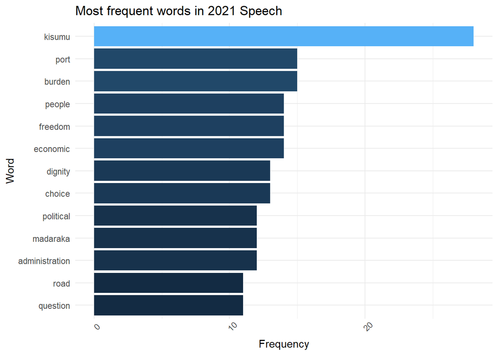

```r
Madaraka_Speech_tidy %>%
  filter(n>10 & doc_id == "2021.txt") %>%
  ggplot(aes(x=n, y=reorder(word, n), fill=n)) +
  geom_col(show.legend=FALSE) +
  labs(
    x = "Frequency",
    y = "Word",
    title = "Most frequent words in 2021 Speech"
  ) +
  theme_minimal() +
  theme(axis.text.x = element_text(angle = 45))
```

# 9: Analyzing n-grams

An n-gram is a combination of consecutive words of length n. Each bigram (n = 2), for example, consist of two words

```r
Speech_bigram_f = function(x){
  speech_f = unnest_tokens(x, bigram, text, token = "ngrams", n = 2)
  return(speech_f)
}

Speech_bigrams = Speech_bigram_f(Speech)
Speech_bigrams
```

```
## readtext object consisting of 8940 documents and 0 docvars.
## # Description: df [8,940 x 3]
##   doc_id   bigram              text
##   <chr>    <chr>               <chr>
## 1 2020.txt today’s celebration "\"\"..."
## 2 2020.txt celebration is      "\"\"..."
## 3 2020.txt is taking           "\"\"..."
## 4 2020.txt taking place        "\"\"..."
## 5 2020.txt place in            "\"\"..."
## 6 2020.txt in an               "\"\"..."
## # ... with 8,934 more rows
```

```r
Speech_2020_bigrams = Speech_bigram_f(Speech_2020)
Speech_2020_bigrams
```

```
## readtext object consisting of 3955 documents and 0 docvars.
## # Description: df [3,955 x 3]
##   doc_id   bigram              text
##   <chr>    <chr>               <chr>
## 1 2020.txt today’s celebration "\"\"..."
## 2 2020.txt celebration is      "\"\"..."
## 3 2020.txt is taking           "\"\"..."
## 4 2020.txt taking place        "\"\"..."
## 5 2020.txt place in            "\"\"..."
## 6 2020.txt in an               "\"\"..."
## # ... with 3,949 more rows
```

```r
Speech_2021_bigrams = Speech_bigram_f(Speech_2021)
Speech_2021_bigrams
```

```
## readtext object consisting of 4985 documents and 0 docvars.
## # Description: df [4,985 x 3]
##   doc_id   bigram         text
##   <chr>    <chr>          <chr>
## 1 2021.txt fellow kenyans "\"\"..."
## 2 2021.txt kenyans it     "\"\"..."
## 3 2021.txt it gives       "\"\"..."
## 4 2021.txt gives me       "\"\"..."
## 5 2021.txt me great       "\"\"..."
## 6 2021.txt great pleasure "\"\"..."
## # ... with 4,979 more rows
```

## Counting n-grams

```r
Speech_count = function(n_count){
  n_gram_count = count(n_count, bigram) %>% arrange(desc(n))
  return(n_gram_count)
}

Speech_count(Speech_bigrams)
```

```
## readtext object consisting of 6337 documents and 0 docvars.
## # Description: df [6,337 x 3]
##   bigram               n text
##   <chr>            <int> <chr>
## 1 of the              71 "\"\"..."
## 2 in the              43 "\"\"..."
## 3 of our              42 "\"\"..."
## 4 we have             40 "\"\"..."
## 5 founding fathers    34 "\"\"..."
## 6 and the             28 "\"\"..."
## # ... with 6,331 more rows
```

```r
Speech_count(Speech_2020_bigrams)
```

```
## readtext object consisting of 3093 documents and 0 docvars.
## # Description: df [3,093 x 3]
##   bigram               n text
##   <chr>            <int> <chr>
## 1 of the              23 "\"\"..."
## 2 founding fathers    20 "\"\"..."
## 3 in the              20 "\"\"..."
## 4 of our              18 "\"\"..."
## 5 we have             18 "\"\"..."
## 6 our founding        17 "\"\"..."
## # ... with 3,087 more rows
```

```r
Speech_count(Speech_2021_bigrams)
```

```
## readtext object consisting of 3721 documents and 0 docvars.
## # Description: df [3,721 x 3]
##   bigram             n text
##   <chr>          <int> <chr>
## 1 of the            48 "\"\"..."
## 2 of our            24 "\"\"..."
## 3 in the            23 "\"\"..."
## 4 we have           22 "\"\"..."
## 5 and the           20 "\"\"..."
## 6 fellow kenyans    16 "\"\"..."
## # ... with 3,715 more rows
```

## Removing stopwords from n-grams

```r
Speech_bigram_stop = function(no_stop){
  del_stop = separate(no_stop, col = bigram,
           into = c("word1", "word2"),
           sep = " ",
           remove = FALSE)
  return(del_stop)
}

Speech_bigrams_no = Speech_bigram_stop(Speech_bigrams)
Speech_bigrams_no
```

```
## readtext object consisting of 8940 documents and 2 docvars.
## # Description: df [8,940 x 5]
##   doc_id   bigram              word1       word2       text
##   <chr>    <chr>               <chr>       <chr>       <chr>
## 1 2020.txt today’s celebration today’s     celebration "\"\"..."
## 2 2020.txt celebration is      celebration is          "\"\"..."
## 3 2020.txt is taking           is          taking      "\"\"..."
## 4 2020.txt taking place        taking      place       "\"\"..."
## 5 2020.txt place in            place       in          "\"\"..."
## 6 2020.txt in an               in          an          "\"\"..."
## # ... with 8,934 more rows
```

```r
Speech_2020_bigrams_no = Speech_bigram_stop(Speech_2020_bigrams)
Speech_2020_bigrams_no
```

```
## readtext object consisting of 3955 documents and 2 docvars.
## # Description: df [3,955 x 5]
##   doc_id   bigram              word1       word2       text
##   <chr>    <chr>               <chr>       <chr>       <chr>
## 1 2020.txt today’s celebration today’s     celebration "\"\"..."
## 2 2020.txt celebration is      celebration is          "\"\"..."
## 3 2020.txt is taking           is          taking      "\"\"..."
## 4 2020.txt taking place        taking      place       "\"\"..."
## 5 2020.txt place in            place       in          "\"\"..."
## 6 2020.txt in an               in          an          "\"\"..."
## # ... with 3,949 more rows
```

```r
Speech_2021_bigrams_no = Speech_bigram_stop(Speech_2021_bigrams)
Speech_2021_bigrams_no
```

```
## readtext object consisting of 4985 documents and 2 docvars.
## # Description: df [4,985 x 5]
##   doc_id   bigram         word1   word2    text
##   <chr>    <chr>          <chr>   <chr>    <chr>
## 1 2021.txt fellow kenyans fellow  kenyans  "\"\"..."
## 2 2021.txt kenyans it     kenyans it       "\"\"..."
## 3 2021.txt it gives       it      gives    "\"\"..."
## 4 2021.txt gives me       gives   me       "\"\"..."
## 5 2021.txt me great       me      great    "\"\"..."
## 6 2021.txt great pleasure great   pleasure "\"\"..."
## # ... with 4,979 more rows
```

## Removing a row if it contains either words in stop words data

```r
Speech_bigrams_tidy = function(speech_tidy){
  speech_clean = filter(speech_tidy, !word1 %in% stop_words$word & !word2 %in% stop_words$word)
  return(speech_clean)
}

Speech_tidy = Speech_bigrams_tidy(Speech_bigrams_no)
Speech_tidy
```

```
## readtext object consisting of 1170 documents and 2 docvars.
## # Description: df [1,170 x 5]
##   doc_id   bigram                word1          word2       text
##   <chr>    <chr>                 <chr>          <chr>       <chr>
## 1 2020.txt today’s celebration   today’s        celebration "\"\"..."
## 2 2020.txt unconventional manner unconventional manner      "\"\"..."
## 3 2020.txt celebrate madaraka    celebrate      madaraka    "\"\"..."
## 4 2020.txt madaraka day          madaraka       day         "\"\"..."
## 5 2020.txt public gathering      public         gathering   "\"\"..."
## 6 2020.txt covid 19              covid          19          "\"\"..."
## # ... with 1,164 more rows
```

```r
Speech_2020_tidy = Speech_bigrams_tidy(Speech_2020_bigrams_no)
Speech_2020_tidy
```

```
## readtext object consisting of 516 documents and 2 docvars.
## # Description: df [516 x 5]
##   doc_id   bigram                word1          word2       text
##   <chr>    <chr>                 <chr>          <chr>       <chr>
## 1 2020.txt today’s celebration   today’s        celebration "\"\"..."
## 2 2020.txt unconventional manner unconventional manner      "\"\"..."
## 3 2020.txt celebrate madaraka    celebrate      madaraka    "\"\"..."
## 4 2020.txt madaraka day          madaraka       day         "\"\"..."
## 5 2020.txt public gathering      public         gathering   "\"\"..."
## 6 2020.txt covid 19              covid          19          "\"\"..."
## # ... with 510 more rows
```

```r
Speech_2021_tidy = Speech_bigrams_tidy(Speech_2021_bigrams_no)
Speech_2021_tidy
```

```
## readtext object consisting of 654 documents and 2 docvars.
## # Description: df [654 x 5]
##   doc_id   bigram         word1    word2    text
##   <chr>    <chr>          <chr>    <chr>    <chr>
## 1 2021.txt fellow kenyans fellow   kenyans  "\"\"..."
## 2 2021.txt 58th madaraka  58th     madaraka "\"\"..."
## 3 2021.txt madaraka day   madaraka day      "\"\"..."
## 4 2021.txt beaming city   beaming  city     "\"\"..."
## 5 2021.txt entire nyanza  entire   nyanza   "\"\"..."
## 6 2021.txt nyanza region  nyanza   region   "\"\"..."
## # ... with 648 more rows
```

```r
Speech_bigram_count =  function(bigram_count){
  bigram_total = count(bigram_count, bigram, sort = TRUE)
  return(bigram_total)
}

Speech_bigram_count(Speech_tidy)
```

```
## readtext object consisting of 956 documents and 0 docvars.
## # Description: df [956 x 3]
##   bigram                n text
##   <chr>             <int> <chr>
## 1 founding fathers     34 "\"\"..."
## 2 fellow kenyans       25 "\"\"..."
## 3 madaraka day         16 "\"\"..."
## 4 jomo kenyatta         7 "\"\"..."
## 5 2010 constitution     5 "\"\"..."
## 6 national question     5 "\"\"..."
## # ... with 950 more rows
```

```r
Speech_bigram_count(Speech_2020_tidy)
```

```
## readtext object consisting of 444 documents and 0 docvars.
## # Description: df [444 x 3]
##   bigram                   n text
##   <chr>                <int> <chr>
## 1 founding fathers        20 "\"\"..."
## 2 fellow kenyans           9 "\"\"..."
## 3 madaraka day             5 "\"\"..."
## 4 kenyan dream             4 "\"\"..."
## 5 coronavirus pandemic     3 "\"\"..."
## 6 covid 19                 3 "\"\"..."
## # ... with 438 more rows
```

```r
Speech_bigram_count(Speech_2021_tidy)
```

```
## readtext object consisting of 543 documents and 0 docvars.
## # Description: df [543 x 3]
##   bigram                    n text
##   <chr>                 <int> <chr>
## 1 fellow kenyans           16 "\"\"..."
## 2 founding fathers         14 "\"\"..."
## 3 madaraka day             11 "\"\"..."
## 4 national question         5 "\"\"..."
## 5 push investments          5 "\"\"..."
## 6 economic acceleration     4 "\"\"..."
## # ... with 537 more rows
```

## Plotting bigram Frequencies

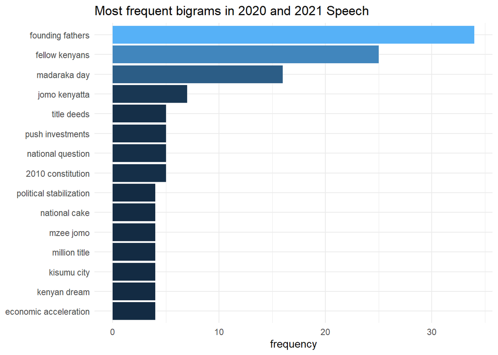

```r
bigram_plot = function(bigram_freq){
  freq_plot = count(bigram_freq,bigram, sort = TRUE) %>%
  filter(n > 3) %>%
  ggplot(aes(x = reorder(bigram, n),
             y = n,
             fill = n)) +
  geom_col(show.legend = FALSE) +
  labs(x = NULL, y = "frequency", title = "Most frequent bigrams in 2020 and 2021 Speech") +
  coord_flip() +
  theme_minimal()
  return(freq_plot)
}

bigram_plot(Speech_tidy)
```

[figure not shown]

```r
bigram_plot(Speech_2020_tidy)
```

[figure not shown]

```r
bigram_plot(Speech_2021_tidy)
```

## tf_idf in n-grams

```r
Speech_idf = function(idf_count){
  idf_no = count(idf_count, doc_id, bigram) %>%
    bind_tf_idf(bigram, doc_id, n)
  return(idf_no)
}
Speech_bigrams_idf = Speech_idf(Speech_tidy)
Speech_bigrams_idf
```

```
## readtext object consisting of 987 documents and 4 docvars.
## # Description: df [987 x 7]
##   doc_id   bigram                n      tf   idf  tf_idf text
##   <chr>    <chr>             <int>   <dbl> <dbl>   <dbl> <chr>
## 1 2020.txt 1,000 kilometres      1 0.00194 0.693 0.00134 "\"\"..."
## 2 2020.txt 1,800 kilometres      1 0.00194 0.693 0.00134 "\"\"..."
## 3 2020.txt 10 times              1 0.00194 0.693 0.00134 "\"\"..."
## 4 2020.txt 11,200 kilometres     1 0.00194 0.693 0.00134 "\"\"..."
## 5 2020.txt 15 times              1 0.00194 0.693 0.00134 "\"\"..."
## 6 2020.txt 19 pandemic           1 0.00194 0.693 0.00134 "\"\"..."
## # ... with 981 more rows
```

```r
Speech_2020_bigrams_idf = Speech_idf(Speech_2020_tidy)
Speech_2020_bigrams_idf
```

```
## readtext object consisting of 444 documents and 4 docvars.
## # Description: df [444 x 7]
##   doc_id   bigram                n      tf   idf tf_idf text
##   <chr>    <chr>             <int>   <dbl> <dbl>  <dbl> <chr>
## 1 2020.txt 1,000 kilometres      1 0.00194     0      0 "\"\"..."
## 2 2020.txt 1,800 kilometres      1 0.00194     0      0 "\"\"..."
## 3 2020.txt 10 times              1 0.00194     0      0 "\"\"..."
## 4 2020.txt 11,200 kilometres     1 0.00194     0      0 "\"\"..."
## 5 2020.txt 15 times              1 0.00194     0      0 "\"\"..."
## 6 2020.txt 19 pandemic           1 0.00194     0      0 "\"\"..."
## # ... with 438 more rows
```

```r
Speech_2021_bigrams_idf = Speech_idf(Speech_2021_tidy)
Speech_2021_bigrams_idf
```

```
## readtext object consisting of 543 documents and 4 docvars.
## # Description: df [543 x 7]
##   doc_id   bigram               n      tf   idf tf_idf text
##   <chr>    <chr>            <int>   <dbl> <dbl>  <dbl> <chr>
## 1 2021.txt 1 billion            1 0.00153     0      0 "\"\"..."
## 2 2021.txt 1,000 acre           1 0.00153     0      0 "\"\"..."
## 3 2021.txt 1,600 passengers     1 0.00153     0      0 "\"\"..."
## 4 2021.txt 10 dialysis          1 0.00153     0      0 "\"\"..."
## 5 2021.txt 10.3 trillion        1 0.00153     0      0 "\"\"..."
## 6 2021.txt 100 days             1 0.00153     0      0 "\"\"..."
## # ... with 537 more rows
```

```r
Speech_sort = function(bigr_idf){
  bigr_rank = arrange(bigr_idf, desc(tf_idf))
  return(bigr_rank)
}

Speech_sort(Speech_bigrams_idf)
```

```
## readtext object consisting of 987 documents and 4 docvars.
## # Description: df [987 x 7]
##   doc_id   bigram                    n      tf   idf  tf_idf text
##   <chr>    <chr>                 <int>   <dbl> <dbl>   <dbl> <chr>
## 1 2020.txt kenyan dream              4 0.00775 0.693 0.00537 "\"\"..."
## 2 2021.txt national question         5 0.00765 0.693 0.00530 "\"\"..."
## 3 2021.txt push investments          5 0.00765 0.693 0.00530 "\"\"..."
## 4 2021.txt economic acceleration     4 0.00612 0.693 0.00424 "\"\"..."
## 5 2021.txt kisumu city               4 0.00612 0.693 0.00424 "\"\"..."
## 6 2021.txt national cake             4 0.00612 0.693 0.00424 "\"\"..."
## # ... with 981 more rows
```

```r
Speech_sort(Speech_2020_bigrams_idf)
```

```
## readtext object consisting of 444 documents and 4 docvars.
## # Description: df [444 x 7]
##   doc_id   bigram                n      tf   idf tf_idf text
##   <chr>    <chr>             <int>   <dbl> <dbl>  <dbl> <chr>
## 1 2020.txt 1,000 kilometres      1 0.00194     0      0 "\"\"..."
## 2 2020.txt 1,800 kilometres      1 0.00194     0      0 "\"\"..."
## 3 2020.txt 10 times              1 0.00194     0      0 "\"\"..."
## 4 2020.txt 11,200 kilometres     1 0.00194     0      0 "\"\"..."
## 5 2020.txt 15 times              1 0.00194     0      0 "\"\"..."
## 6 2020.txt 19 pandemic           1 0.00194     0      0 "\"\"..."
## # ... with 438 more rows
```

```r
Speech_sort(Speech_2021_bigrams_idf)
```

```
## readtext object consisting of 543 documents and 4 docvars.
## # Description: df [543 x 7]
##   doc_id   bigram               n      tf   idf tf_idf text
##   <chr>    <chr>            <int>   <dbl> <dbl>  <dbl> <chr>
## 1 2021.txt 1 billion            1 0.00153     0      0 "\"\"..."
## 2 2021.txt 1,000 acre           1 0.00153     0      0 "\"\"..."
## 3 2021.txt 1,600 passengers     1 0.00153     0      0 "\"\"..."
## 4 2021.txt 10 dialysis          1 0.00153     0      0 "\"\"..."
## 5 2021.txt 10.3 trillion        1 0.00153     0      0 "\"\"..."
## 6 2021.txt 100 days             1 0.00153     0      0 "\"\"..."
## # ... with 537 more rows
```

# 10: tf-idf plot

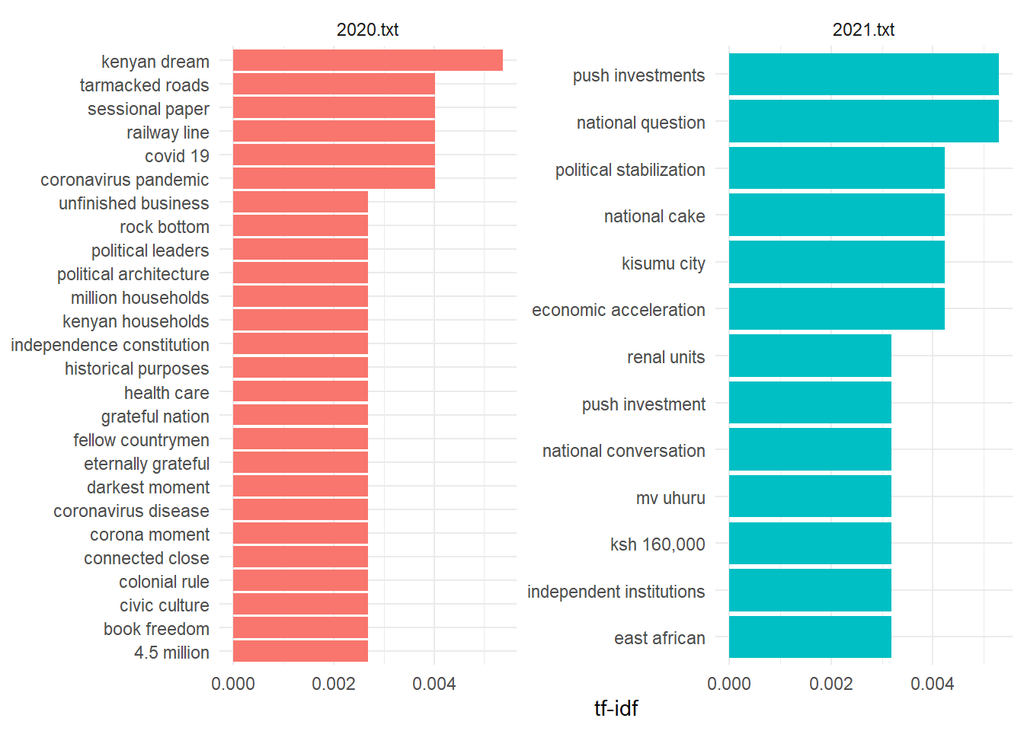

```r
Speech_bigrams_idf %>%
  group_by(doc_id) %>%
  slice_max(tf_idf, n = 10) %>%
  ungroup() %>%
  ggplot() +
  aes(x = tf_idf,
      y = fct_reorder(bigram, tf_idf),
      fill = doc_id) +
  geom_col(show.legend = FALSE) +
  facet_wrap(~ doc_id, scales = "free") +
  labs(x = "tf-idf", y = NULL) +
  theme_minimal()
```

# 11: Creating and Visualizing the Bigrams network

The operation visualizes the words thet commonly co-occur in the bigrams. We first count the bigrams then use ‘graph_from_data_frame()’ command from the igraph package to reformat the data.

```r
Speech_graph = Speech_tidy %>%
  count(word1, word2) %>% # we need the words separated for this graph
  filter(n > 3) %>%
  graph_from_data_frame()
```

Now, plot the graph using `ggraph()` from the eponymous package

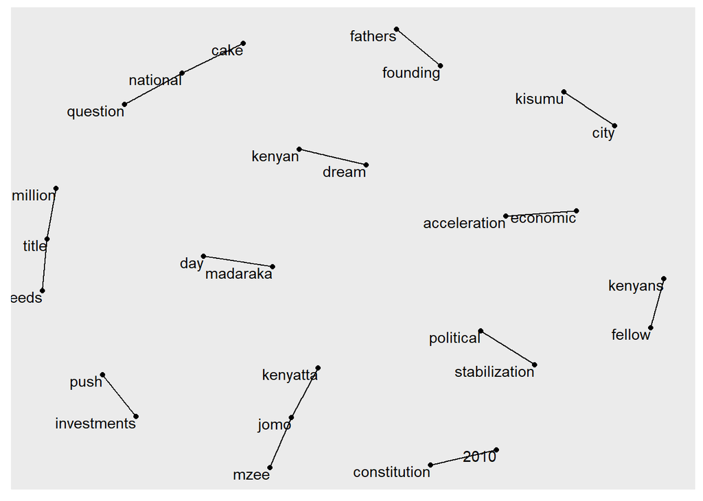

```r
set.seed(2021)
ggraph(Speech_graph, layout = "fr") +
  geom_edge_link() +
  geom_node_point() +
  geom_node_text(aes(label = name),
                 vjust = 1, hjust = 1)
```

The graph now shows the words that occur together. We can improve the graph by including arrows to show how the bigrams are ordered.

Create a object ‘a’ that creates the arrow shape.

```r
a <- grid::arrow(type = "closed", length = unit(.15, "inches"))
```

Now plot the graph.

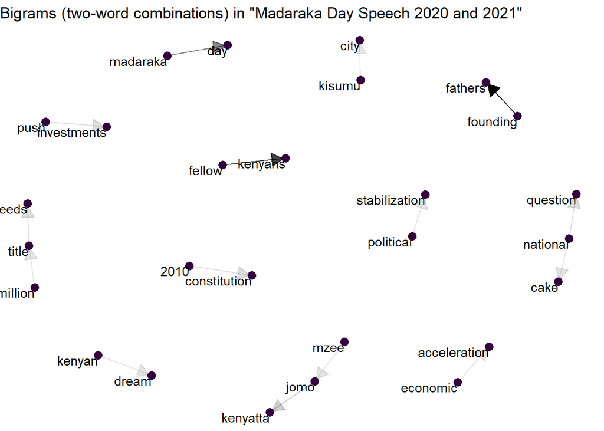

```r
ggraph(Speech_graph, layout = "fr") +
  geom_edge_link(aes(edge_alpha = n), # the links are more transparent if the bigram is rare
                 show.legend = FALSE,
                 arrow = a, end_cap = circle(.03, 'inches')) + #adding the arrows, making sure they don't touch the node
  geom_node_point(color = "#34013f", size = 3) + # larger, purple nodes
  geom_node_text(aes(label = name), vjust = 1, hjust = 1) +
  theme_void() +
  labs(title = 'Bigrams (two-word combinations) in "Madaraka Day Speech 2020 and 2021"')
```